## Example of biomass and energy showing different behaviors

For about 1/4 of routes, biomass and total energy use have different “syndromes” (coupled trend, decoupled trend, no trend):

| Same_syndrome | n | total | prop |
| --- | --- | --- | --- |
| Different syndromes | 176 | 739 | 0.24 |
| Same syndromes for both currencies | 563 | 739 | 0.76 |

What stands out to me about this is that, in instances where they show different “syndromes” (left panel), usually the slope for energy use is less positive than for biomass (90% of the time for these routes; this is somewhat overrepresented compared to 78% of the time for routes with the same “syndrome”).

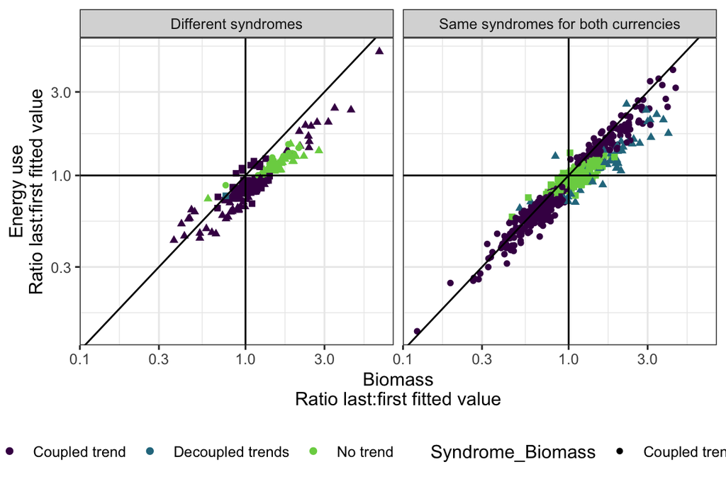

| Same_syndrome | Biomass_more_positive_than_energy | n | total | prop |
| --- | --- | --- | --- | --- |
| Different syndromes | FALSE | 17 | 176 | 0.0965909 |
| Different syndromes | TRUE | 159 | 176 | 0.9034091 |
| Same syndromes for both currencies | FALSE | 119 | 563 | 0.2113677 |
| Same syndromes for both currencies | TRUE | 444 | 563 | 0.7886323 |

## Sample route with different syndromes

Here is an example of a route where biomass shows the “Decoupled trend” syndrome and energy use shows a “coupled trend”. For this route, biomass shows a positive slope (ratio of last:first value of 1.22) and energy use a negative slope (ratio of last:first of .9). Individual abundance shows a decline (ratio of last:first of .7). Because the slope for biomass is more positive than for individual abundance (1.22 compared to .7; recall that ratios > 1 are increasing and < 1 are decreasing), we know that community-wide mean body size has increased for this route. Because energy use scales nonlinearly with biomass with an exponent < 1, community-wide mean *per capita metabolic rate* has not increased as much as mean body size has (but has still increased, because the slope for energy use is less negative than for individual abundance).

| matssname | ratio_sim_Biomass | ratio_sim_Energy_use | ratio_real_Biomass | ratio_real_Energy_use | modelcomplexity_Biomass | modelcomplexity_Energy_use | winning_formula_Biomass | winning_formula_Energy_use | Syndrome_Biomass | Syndrome_Energy_use | Same_syndrome |
| --- | --- | --- | --- | --- | --- | --- | --- | --- | --- | --- | --- |
| bbs_rtrg_6_39 | 0.7044827 | 0.6959935 | 1.227789 | 0.8941509 | 4 | 2 | timeperiod * source | timeperiod | Decoupled trends | Coupled trend | Different syndromes |

This intuition plays out if we calculate the mean body mass and mean metabolic flux off of the ISDs for the first and last 5-year periods. Total abundance has declined (end:begin ratio of .7). Mean metabolic rate and mean biomass have both increased, but the increase in biomass is greater than the increase in metabolic rate (1.63 vs 1.24).

| timeperiod | totaln | mean_body_mass | mean_metabolic_flux |
| --- | --- | --- | --- |
| begin | 7196 | 80.80702 | 221.3931 |
| end | 5011 | 132.20048 | 275.8563 |

| totaln_ratio | mean_body_mass_ratio | mean_metabolic_flux_ratio |
| --- | --- | --- |
| 0.6963591 | 1.636002 | 1.246002 |

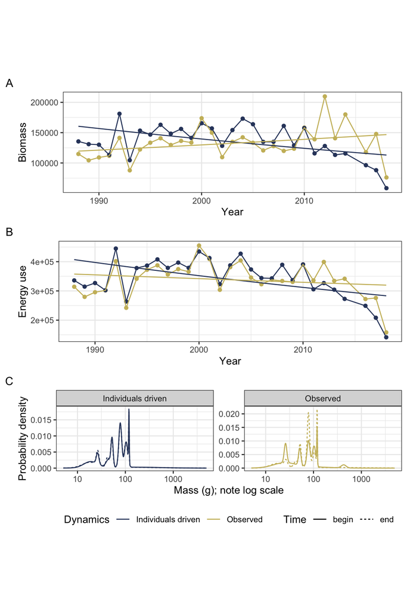

## Sample route with the same syndrome

| matssname | ratio_sim_Biomass | ratio_sim_Energy_use | ratio_real_Biomass | ratio_real_Energy_use | modelcomplexity_Biomass | modelcomplexity_Energy_use | winning_formula_Biomass | winning_formula_Energy_use | Syndrome_Biomass | Syndrome_Energy_use | Same_syndrome |
| --- | --- | --- | --- | --- | --- | --- | --- | --- | --- | --- | --- |
| bbs_rtrg_44_17 | 0.7337782 | 0.7449154 | 1.297189 | 1.069638 | 4 | 4 | timeperiod * source | timeperiod * source | Decoupled trends | Decoupled trends | Same syndromes for both currencies |

| timeperiod | totaln | mean_body_mass | mean_metabolic_flux |
| --- | --- | --- | --- |
| begin | 3768 | 77.14425 | 205.9062 |
| end | 2955 | 101.87131 | 247.9020 |

| totaln_ratio | mean_body_mass_ratio | mean_metabolic_flux_ratio |
| --- | --- | --- |
| 0.7842357 | 1.32053 | 1.203956 |

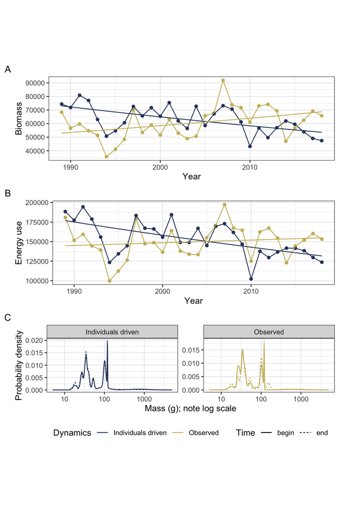